# Visualisation exercises – (partial solutions)

## Exercises from R4DS

Exercises from R4DS are given below. You can use the qmd-file as a starting point to make a document of solutions to the exercises. Simply insert code chunks below each question with your code to solve the given task.

### Loading the `tidyverse` and `palmerpenguins`

```r
library(tidyverse)
library(palmerpenguins)
```

## 1.2.5 Exercises

1. How many rows are in `penguins`? How many columns?

   ```r
   nrow(penguins)
   ```

   ```
   [1] 344
   ```

   ```r
   ncol(penguins)
   ```

   ```
   [1] 8
   ```

2. What does the `bill_depth_mm` variable in the `penguins` data frame describe? Read the help for `?penguins` to find out.

   *a number denoting bill depth (millimeters)*
3. Make a scatterplot of `bill_depth_mm` vs. `bill_length_mm`. That is, make a scatterplot with `bill_depth_mm` on the y-axis and `bill_length_mm` on the x-axis. Describe the relationship between these two variables.

4. What happens if you make a scatterplot of `species` vs. `bill_depth_mm`? What might be a better choice of geom?

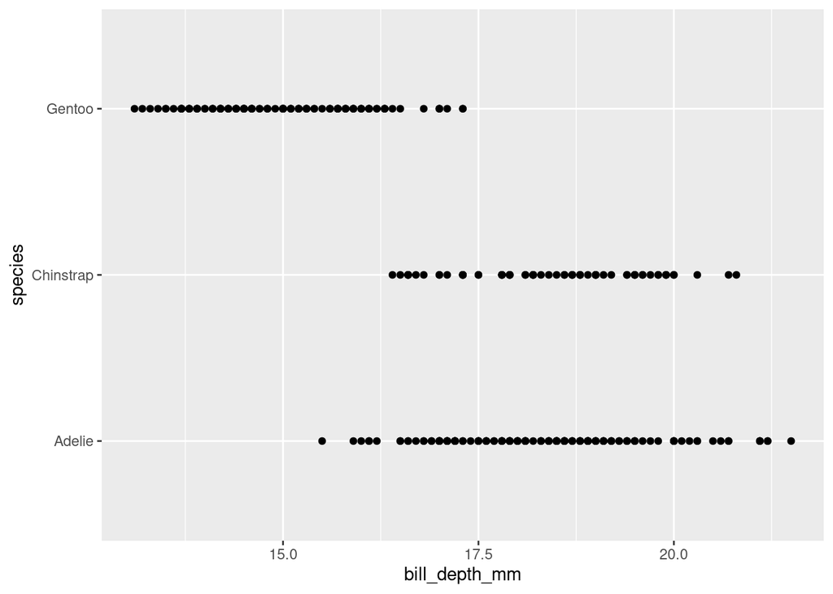

   ```r
   penguins |>
     ggplot(aes(x = bill_depth_mm, y = species)) + geom_point()
   ```

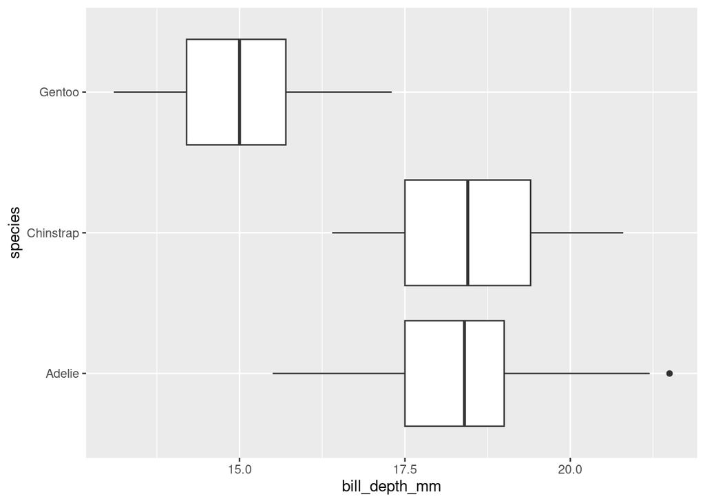

   ```r
   penguins |>
     ggplot(aes(x = bill_depth_mm, y = species)) + geom_boxplot()
   ```

5. Why does the following give an error and how would you fix it?

   ```r
   ggplot(data = penguins) +
     geom_point()
   ```

6. What does the `na.rm` argument do in `geom_point()`? What is the default value of the argument? Create a scatterplot where you successfully use this argument set to `TRUE`.

7. Add the following caption to the plot you made in the previous exercise: “Data come from the palmerpenguins package.” Hint: Take a look at the documentation for `labs()`.

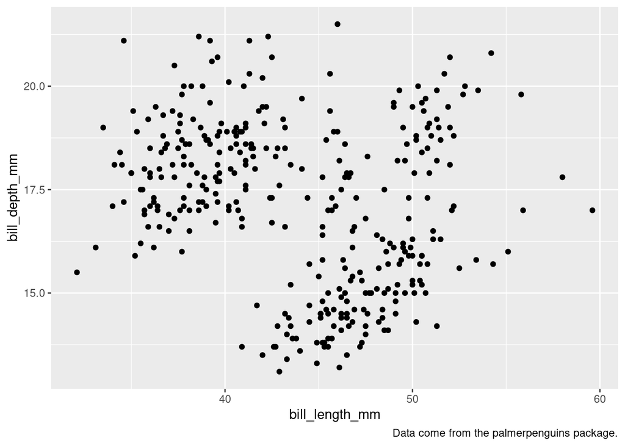

   ```r
   penguins |> ggplot() +
     geom_point(aes(bill_length_mm, bill_depth_mm), na.rm = TRUE) +
     labs(caption = "Data come from the palmerpenguins package.")
   ```

8. Recreate the following visualization. What aesthetic should `bill_depth_mm` be mapped to? And should it be mapped at the global level or at the geom level?

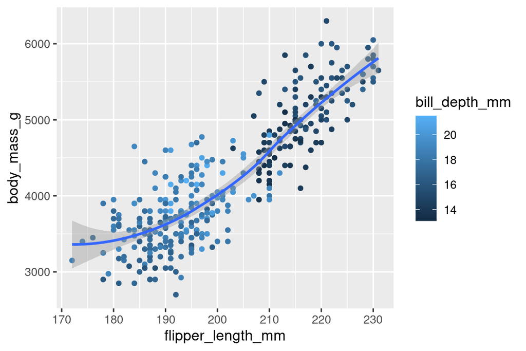

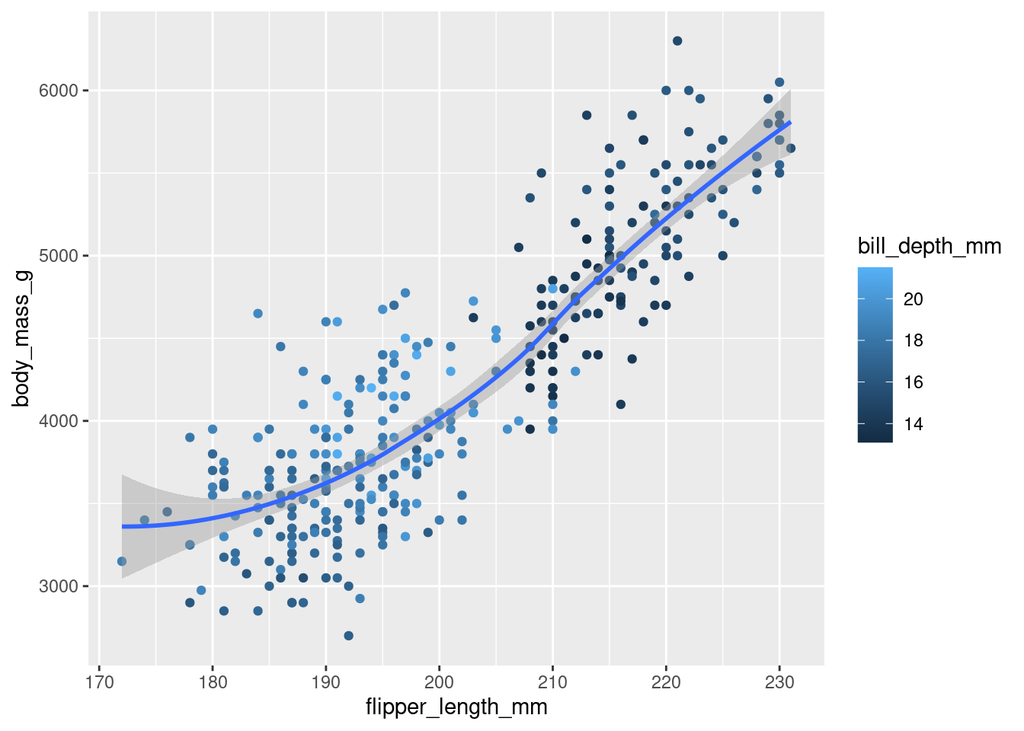

   ```r
   penguins |> ggplot(aes(x = flipper_length_mm, y = body_mass_g)) +
     geom_point(aes(colour = bill_depth_mm), na.rm = TRUE) +
     geom_smooth(na.rm = TRUE)
   ```

9. Run this code in your head and predict what the output will look like. Then, run the code in R and check your predictions.

   ```r
   ggplot(
     data = penguins,
     mapping = aes(x = flipper_length_mm, y = body_mass_g, color = island)
   ) +
     geom_point() +
     geom_smooth(se = FALSE)
   ```

10. Will these two graphs look different? Why/why not?

    ```r
    ggplot(
      data = penguins,
      mapping = aes(x = flipper_length_mm, y = body_mass_g)
    ) +
      geom_point() +
      geom_smooth()

    ggplot() +
      geom_point(
        data = penguins,
        mapping = aes(x = flipper_length_mm, y = body_mass_g)
      ) +
      geom_smooth(
        data = penguins,
        mapping = aes(x = flipper_length_mm, y = body_mass_g)
      )
    ```

    *No difference. Both layers specify the same aesthetic mapping as the single global layer.*

### 1.4.3 Exercises

1. Make a bar plot of `species` of `penguins`, where you assign `species` to the `y` aesthetic. How is this plot different?

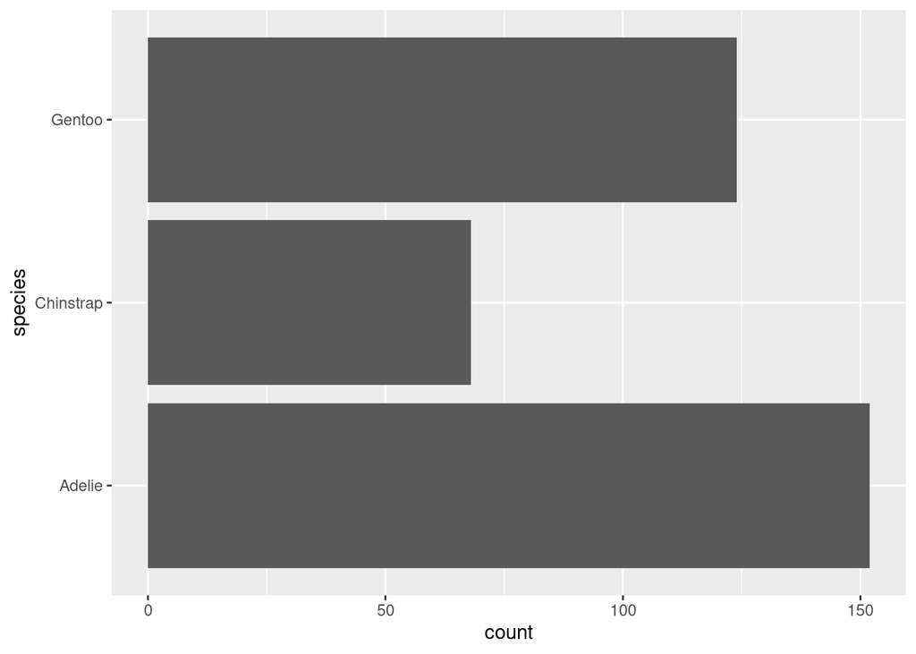

   ```r
   penguins |>
     ggplot(aes(y = species)) +
     geom_bar()
   ```

2. How are the following two plots different? Which aesthetic, `color` or `fill`, is more useful for changing the color of bars?

   ```r
   ggplot(penguins, aes(x = species)) +
     geom_bar(color = "red")

   ggplot(penguins, aes(x = species)) +
     geom_bar(fill = "red")
   ```

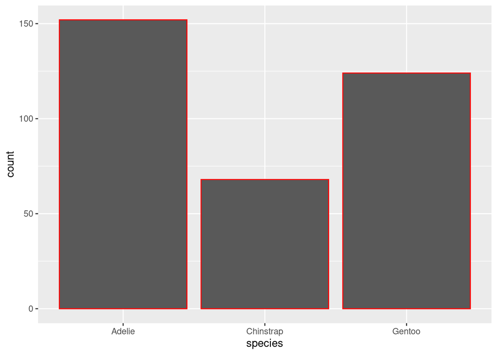

   ```r
   ggplot(penguins, aes(x = species)) +
     geom_bar(color = "red")
   ```

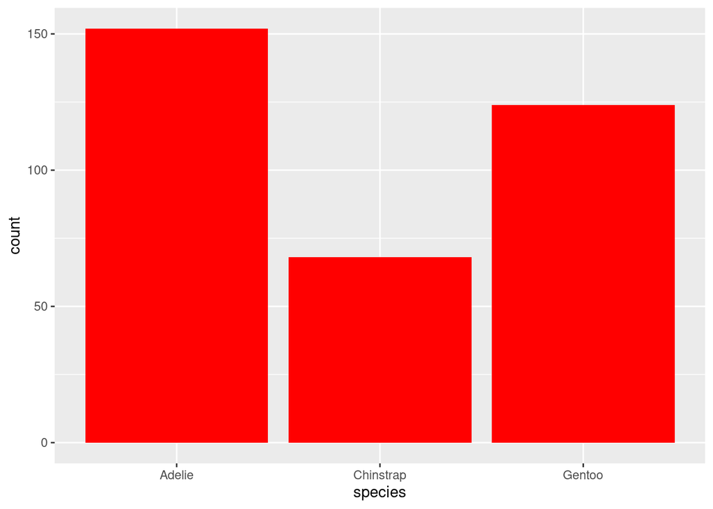

   ```r
   ggplot(penguins, aes(x = species)) +
     geom_bar(fill = "red")
   ```

3. What does the `bins` argument in `geom_histogram()` do?

   **Set the number of bins on the x-axis.**
4. Make a histogram of the `carat` variable in the `diamonds` dataset that is available when you load the tidyverse package. Experiment with different binwidths. What binwidth reveals the most interesting patterns?

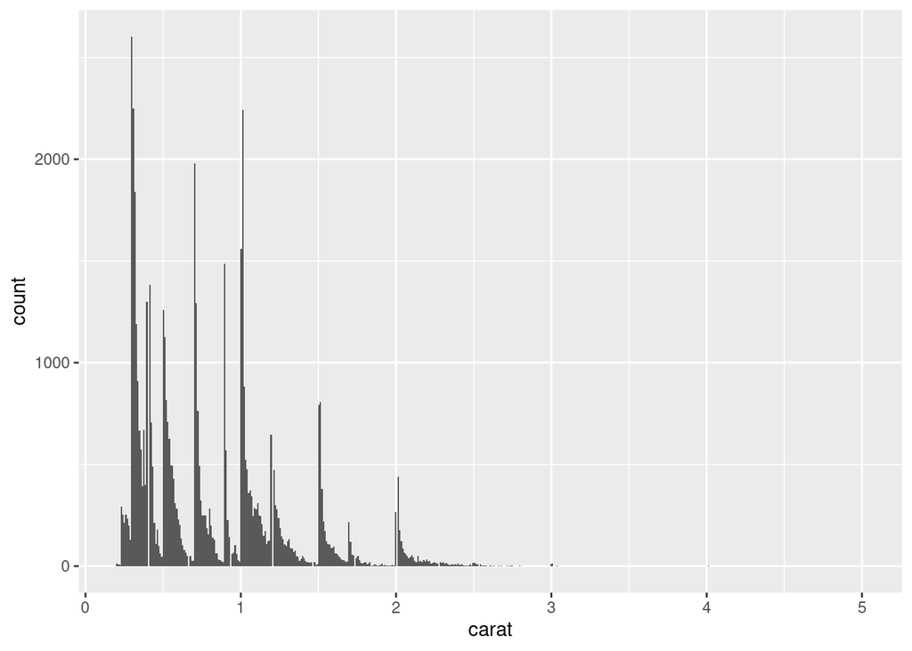

   ```r
   diamonds |>
     ggplot(aes(x=carat)) +
     geom_histogram(bins = 500)
   ```